# Question

Carlos necesita determinar el valor del cateto x del triángulo rectángulo representado en el diagrama.

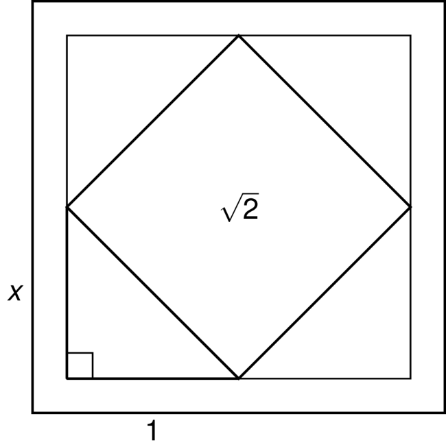

Para esto, efectúa correctamente el siguiente procedimiento:

**Paso 1.** Calcula la hipotenusa $\sqrt{x^2 + 1^2}$ y obtiene $\sqrt{2}$.

**Paso 2.** El resultado del paso 1 lo eleva al cuadrado y obtiene como resultado el número 2.

¿Cuál es el valor del cateto $x$?

## Answerlist

- $x = 1$
- $x = 4$
- $x = \sqrt{7}$
- $x = 2$

# Solution

Para resolver este problema, debemos analizar la información geométrica y aplicar el teorema de Pitágoras correctamente.

**Resolución paso a paso:**

Del **Paso 1**: $\sqrt{x^2 + 1^2} = \sqrt{2}$

Del **Paso 2**: $(\sqrt{2})^2 = 2$

Verificamos el **Paso 2**: $(\sqrt{2})^2 = 2$ (correcto)

Sustituyendo en la ecuación del **Paso 1**: $x^2 + 1^2 = 2$

Resolviendo: $x^2 + 1 = 2$

Por lo tanto: $x^2 = 2 - 1 = 1$

Entonces: $x = 1$

**Verificación geométrica:** Si $x = 1$, entonces $\sqrt{1^2 + 1^2} = \sqrt{2}$, y $(\sqrt{2})^2 = 2$ (verificado)

## Answerlist

- Verdadero. Aplicando correctamente el teorema de Pitágoras: $x^2 + 1 = 2$, por lo tanto $x = 1$.
- Falso. Error: Error: aplica incorrectamente el teorema de Pitágoras
- Falso. Error: Error: usa el resultado final (2) como valor del cateto
- Falso. Error: Error: confunde la diagonal con el cateto buscado

# Meta-information

exname: Cateto triangulo rectangulo teorema Pitagoras extype: schoice exsolution: 1000 exshuffle: TRUE exsection: Geometria/Teorema de Pitagoras

# Metadatos ICFES obligatorios

icfes: competencia: formulacion_ejecucion nivel_dificultad: 2 contenido: categoria: geometria tipo: generico contexto: matematico eje_axial: eje2 componente: geometrico_metrico